# Assessing the Association Between Accident Injury Severity and NCAP Car Safety Ratings

Lucy D’Agostino McGowan & Ryan Jarrett

### Background

[We are interested in evaluating how effective these ratings are in preventing passenger injury in real world crashes]

### Methods

#### Data Sources

- National Automotive Sampling System (NASS) General Estimates System (GES) for the years 2011-2014
  - Maximum injury severity
  - Accident condition variables (weather, point of impact, type of accident etc.)
  - Passenger-level variables (age, sex, alcohol, seat-belt use, etc.)
- NHTSA saftey ratings (obtained from www.safercar.gov)
  - Overall safety rating
  - Weight of the vehicle
  - **Note**: we obtained this data by scraping from the website; we attempted to contact NHTSA for a comprehensive list of ratings that was potentially more reliable than this method, but were not able to obtain one. Please let us know if you have access to this dataset!

#### Saftey Ratings

- Safety tests are conducted by the NHTSA on a subset of cars each year
- Tests are conducted under highly controlled circumstances with test dummies in the driver and front passenger seats
  - frontal collision at 35 mph
  - side collision at 38.5 mph
- Each car model tested subsequently receives (among others) an overall rating out of 5 stars.
- **Safety ratings are only comparable within weight class**

#### Weighting Scheme

- **Nationally representative probability sample** selected from all police-reported crashes.
- **Eligibility**:
  - A Police Accident Report must be completed for the crash
  - Crash must involve at least one motor vehicle traveling on a trafficway
  - Crash must result in property damage, injury, or death

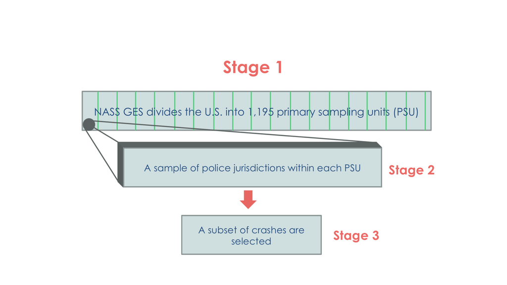

1. **Stage 1** is a sample of geographic areas, called Primary Sampling Units (PSUs), from across the United States. The NASS GES divides the United States into 1,195 PSUs.
2. **Stage 2** is a sampling of police jurisdictions within each PSU based upon probability proportional to the number of crashes investigated in a given jurisdiction. *An average of seven police jurisdictions have been selected within each PSU*.
3. **Stage 3** is the selection of crashes within the sampled police jurisdictions.

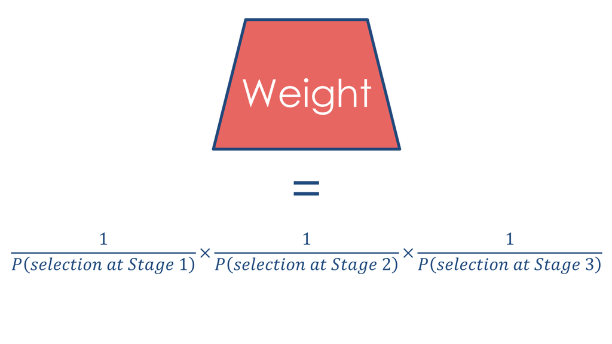

The weight is the product of the inverse of the probabilities of selection at each of the three stages in the sampling process.

For more information on the sample scheme: [click here](https://crashstats.nhtsa.dot.gov/Api/Public/ViewPublication/812320).

#### Design

- Incorporating the design in the statistical analysis is vital
- In order to obtain the correct standard error estimates for a subpopulation, we need to properly account for the weights and design
- All analysis was completed using `R`
- We primarily utilized the **survey** package:
  - T. Lumley (2014) “survey: analysis of complex survey samples”. R package version 3.30.
  - T. Lumley (2004) Analysis of complex survey samples. Journal of Statistical Software 9(1): 1-19

#### Variable Definitions

[**Outcome**: Maximum Injury Severity within Vehicle]

*0*: No injury

*1*: Some injury (ranging from possible to fatal)

[**Predictor of Interest**: NHTSA Overall Ratings]

*5 Stars*: Injury risk for this vehicle is much less than average

*4 Stars*: Injury risk for this vehicle is less than average to average

*2 or 3 Stars*: Injury risk for this vehicle is average to greater than average or greater than average *There were no one star vehicles in our data set*

**Adjusted for:**

- Seat restraint misuse
- Speeding
- Indicator for interstate highway
- Weather
- Impact location
- Alcohol involvement
- Indicator for rollover
- Indicator for airbag deployment
- Manner of collision
- Age
- Sex
- Age x Sex

**Fit a logistic model:**

- Injured versus uninjured
- Adjusted for all covariates shown previously
- Fit an interaction between rating x weight class

### Results

- Weighted sample: N=2,595,190
- Unweighted sample: N=19,428
- Merged 4 years of data (2011-2014)
- Included vehicles:
  - had a safety rating (2011+)
  - had passengers with known injury severity

| Maximum Injury in Vehicle | Weighted frequency (%) |
| --- | --- |
| No injury | 2,170,141.59 (83.6%) |
| Injury | 425,048.1 (16.4%) |

[output not shown]

Figures 1, 2, and 3 show the injury & saftey ratings by weight class. Figure 2 shows the concerning result that 2-3 star rated cars in the mid-size weight class have proportionally fewer injuries. These results hold true after adjusting for the covariates, this result held true (Figure 4). **Here is where we would love your input! Perhaps we missed an important confounder. All of the data can be found [here](https://github.com/LucyMcGowan/NHTSA-safety-analysis) along with our [raw analysis files](https://github.com/LucyMcGowan/NHTSA-safety-analysis/raw)**

[interactive chart not shown]

Figure 1: Maximum Injury by Saftey Rating (Weight <3000lb)

[interactive chart not shown]

Figure 2: Maximum Injury by Saftey Rating (Weight 3000-3499lb)

[interactive chart not shown]

Figure 3: Maximum Injury by Saftey Rating (Weight >3500lb)

[interactive chart not shown]

Figure 4: Percent Injured by rating

#### Limitations

- This analysis was limited to vehicles that were in accidents – we don’t know the distribution of ratings in the general population
- It is possible that 4 or 5 star cars are more likely to be rated than 2 or 3 star cars
- Limiting ourselves to using ratings from 2011-2014 drastically decreased our sample size and limited the information about other cars involved in each accident
- We were only able to observe 330 unique make/model/year combinations